# PISA 2012 Dataset Exploration

## by Isha

## Investigation Overview

In this investigation, I explore the Programme for International Student Assessment (PISA) dataset. My goals are:

1. What are the general scores for maths, reading and science?
2. Are there differences in achievement based on gender or location (country)?
3. Are there differences in achievement based on parents' educational qualifications?

## Dataset Overview

1. 485,490 Students
2. 64 Countries
3. 635 Features e.g.
   - Gender
   - Parents' Educational Qualifications
   - Maths, Reading and Science Scores
   - Family Wealth (e.g. possession of own room or Internet)
4. All in a data csv file of 2.75 GB(!)

## Gender

The proportion of male and female students are quite balanced at 49.52% and 50.48% respectively.

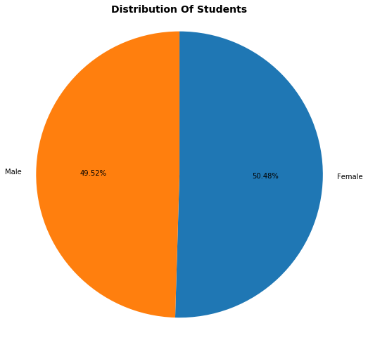

```python
plt.figure(figsize=[14.70, 8.27])
labels = ['Female', 'Male']
plt.pie(df['ST04Q01'].value_counts(), labels=labels, autopct='%.2f%%', startangle=90, counterclock=False)
plt.axis('square')
plt.title('Distribution of Students'.title(), fontsize=14, weight='bold')
plt.show()
```

## Mean Maths Score by Gender

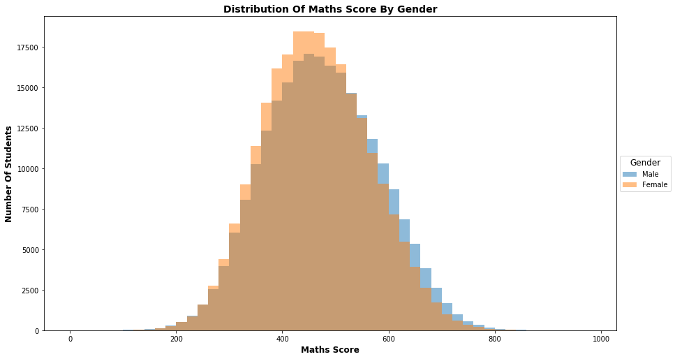

```python
# Histogram for both males and females' maths scores
binsize = 20
bins = np.arange(0, df['PV1MATH'].max()+binsize, binsize)

plt.figure(figsize=[14.70, 8.27])
plt.hist(data=df[df['ST04Q01']=='Male'], x='PV1MATH', bins = bins, label='Male', alpha=0.5)
plt.hist(data=df[df['ST04Q01']=='Female'], x='PV1MATH', bins = bins, label='Female', alpha=0.5)
plt.title('Distribution of Maths Score by Gender'.title(), fontsize=14, weight='bold')
plt.xlabel('Maths Score'.title(), fontsize=12, weight='bold')
plt.ylabel('Number of Students'.title(), fontsize=12, weight='bold')
plt.legend(loc='center left', bbox_to_anchor=(1, 0.5), title='Gender', title_fontsize = 12)
plt.show()
```

## Mean Maths Score by Country

The top 3 countries with the highest mean maths scores are China-Shanghai, Singapore and Hong Kong-China. The bottom 3 countries with the lowest mean maths scores are Peru, Indonesia and Qatar. Interestingly hey are all non-OECD countries.

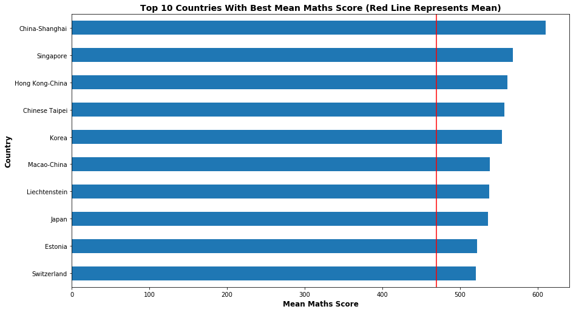

```python
plt.figure(figsize=[14.70, 8.27])
df.groupby('CNT').mean()['PV1MATH'].sort_values(ascending=True).tail(10).plot(kind='barh')
plt.title('Top 10 Countries with Best Mean Maths Score (red line represents mean)'.title(), fontsize=14, weight='bold')
plt.xlabel('Mean Maths Score'.title(), fontsize=12, weight='bold')
plt.ylabel('Country'.title(), fontsize=12, weight='bold')
plt.axvline(df['PV1MATH'].mean(), color='r')
plt.show()
```

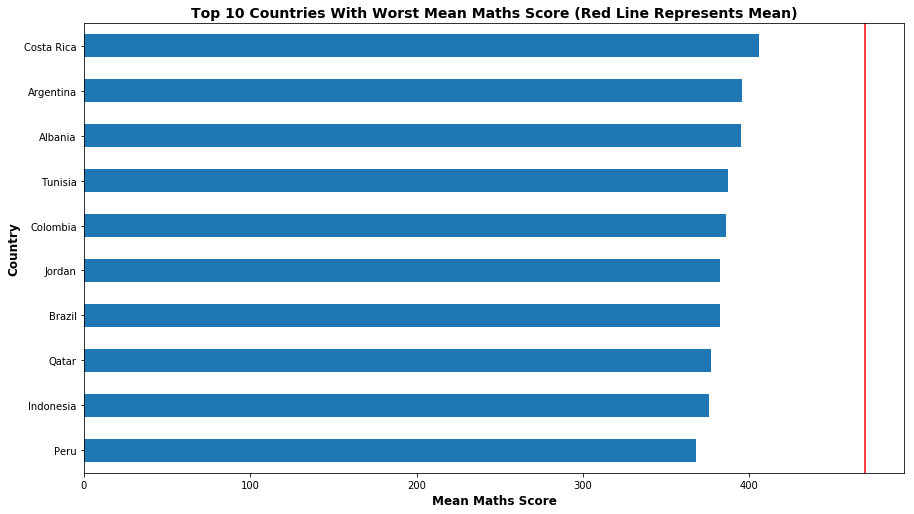

```python
plt.figure(figsize=[14.70, 8.27])
df.groupby('CNT').mean()['PV1MATH'].sort_values(ascending=True).head(10).plot(kind='barh')
plt.title('Top 10 Countries with Worst Mean Maths Score (red line represents mean)'.title(), fontsize=14, weight='bold')
plt.xlabel('Mean Maths Score'.title(), fontsize=12, weight='bold')
plt.ylabel('Country'.title(), fontsize=12, weight='bold')
plt.axvline(df['PV1MATH'].mean(), color='r')
plt.show()
```

## Mean Maths Score by OECD/Non-OECD Country

For OECD countries, the math score looks normally distributed with a mean score around 500, with a peak of more than 20000 students achieving the mean score.

For non-OECD countries, the math score looks slightly right-skewed (i.e. more students obtain lower scores). Compared with OECD countries, the mean math score for non-OECD countries looks lower at about 400, with a lower peak of about 15000 students.

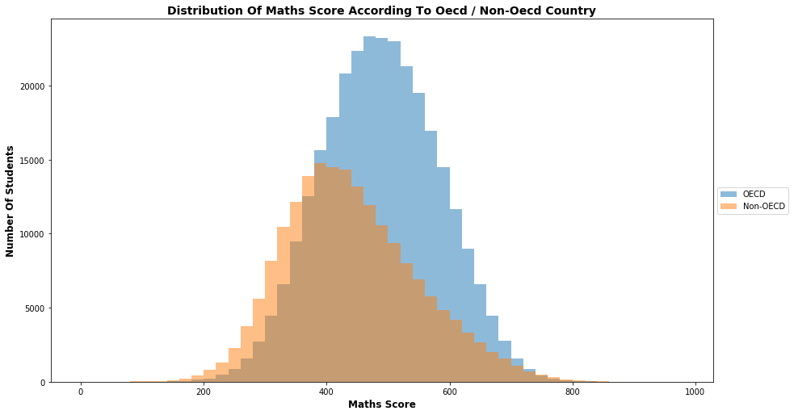

```python
# Histogram for both males and females' maths scores
binsize = 20
bins = np.arange(0, df['PV1MATH'].max()+binsize, binsize)

plt.figure(figsize=[14.70, 8.27])
plt.hist(data=df[df['OECD']=='OECD'], x='PV1MATH', bins = bins, label='OECD', alpha=0.5)
plt.hist(data=df[df['OECD']=='Non-OECD'], x='PV1MATH', bins = bins, label='Non-OECD', alpha=0.5)
plt.title('Distribution of Maths Score according to OECD / non-OECD Country'.title(), fontsize=14, weight='bold')
plt.xlabel('Maths Score'.title(), fontsize=12, weight='bold')
plt.ylabel('Number of Students'.title(), fontsize=12, weight='bold')
plt.legend(loc='center left', bbox_to_anchor=(1, 0.5), title='', title_fontsize = 12);
plt.show()
```

## Distribution of Maths Score (OECD Countries)

There are some countries with sharp peaks at the mean such as Canada, Spain, Italy and Mexico. Other countries have distributions that are not as steep and are more mild in comparison.

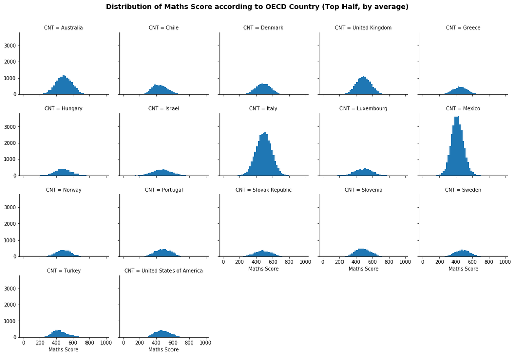

```python
# FacetGrid for distribution of maths score according to OECD country (top half)
#plt.figure(figsize=[14.70, 8.27])
df['Maths Score'] = df['PV1MATH']
binsize = 20
bins = np.arange(0, df['Maths Score'].max()+binsize, binsize)

plt.tight_layout()
g = sb.FacetGrid(df[(df['OECD']=='OECD') & (df['CNT'].isin(OECD_top_countries))], col='CNT', col_wrap=5, margin_titles=True, height = 10.27/4, aspect = (14.70/5)/(10.27/4))
g.map(plt.hist, 'Maths Score', bins = bins)
g.fig.subplots_adjust(top=0.90)
g.fig.suptitle('Distribution of Maths Score according to OECD Country (Top Half, by average)', fontsize = 14, weight = "bold")
plt.show()
```

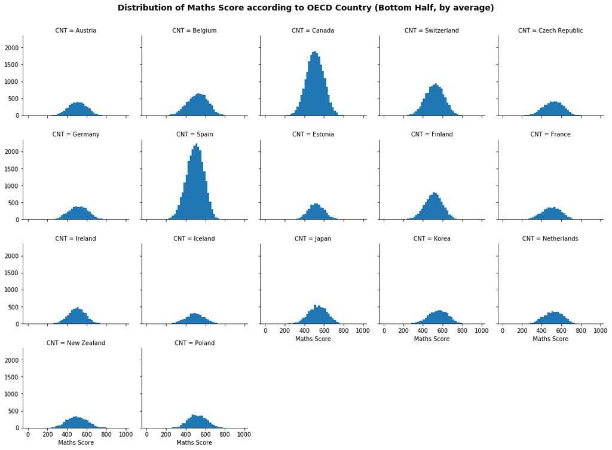

```python
# FacetGrid for distribution of maths score according to OECD country (bottom half)
#plt.figure(figsize=[14.70, 8.27])
df['Maths Score'] = df['PV1MATH']
binsize = 20
bins = np.arange(0, df['Maths Score'].max()+binsize, binsize)

plt.tight_layout();
g = sb.FacetGrid(df[(df['OECD']=='OECD') & (df['CNT'].isin(OECD_bottom_countries))], col='CNT', col_wrap=5, margin_titles=True, height = 10.27/4, aspect = (14.70/5)/(10.27/4))
g.map(plt.hist, 'Maths Score', bins = bins);
g.fig.suptitle('Distribution of Maths Score according to OECD Country (Bottom Half, by average)', fontsize = 14, weight = "bold", y = 1.04);
```

## Distribution of Maths Score (Non-OECD Countries)

For non-OECD countries, we can see that not all the maths score distributions are symmetical about the mean. Some are skewed such as Chinese Taipei and Singapore. Interestingly, the distribution for Liechtenstein is almost totally flat.

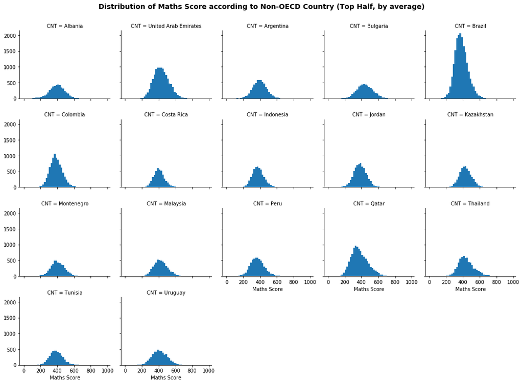

```python
# FacetGrid for distribution of maths score according to non-OECD country (top half)
#plt.figure(figsize=[14.70, 8.27])
df['Maths Score'] = df['PV1MATH']
binsize = 20
bins = np.arange(0, df['Maths Score'].max()+binsize, binsize)

plt.tight_layout();
g = sb.FacetGrid(df[(df['OECD']=='Non-OECD') & (df['CNT'].isin(nonOECD_top_countries))], col='CNT', col_wrap=5, margin_titles=True, height = 10.27/4, aspect = (14.70/5)/(10.27/4))
g.map(plt.hist, 'Maths Score', bins = bins)
g.fig.suptitle('Distribution of Maths Score according to Non-OECD Country (Top Half, by average)', fontsize = 14, weight = "bold", y = 1.04);
```

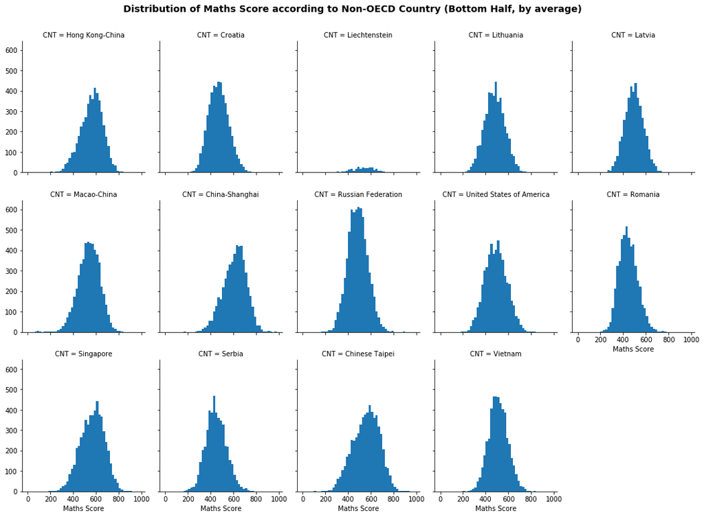

```python
# FacetGrid for distribution of maths score according to non-OECD country (bottom half)
#plt.figure(figsize=[14.70, 8.27])
df['Maths Score'] = df['PV1MATH']
binsize = 20
bins = np.arange(0, df['Maths Score'].max()+binsize, binsize)

plt.tight_layout();
g = sb.FacetGrid(df[(df['OECD']=='Non-OECD') & (df['CNT'].isin(nonOECD_bottom_countries))], col='CNT', col_wrap=5, margin_titles=True, height = 10.27/3, aspect = (14.70/5)/(10.27/3))
g.map(plt.hist, 'Maths Score', bins = bins)
g.fig.suptitle('Distribution of Maths Score according to Non-OECD Country (Bottom Half, by average)', fontsize = 14, weight = "bold", y = 1.04);
```

## Distribution of Maths Score (By Country and Gender)

In general, there is no major difference in the distribution for the maths score according to gender, for all the OECD countries.

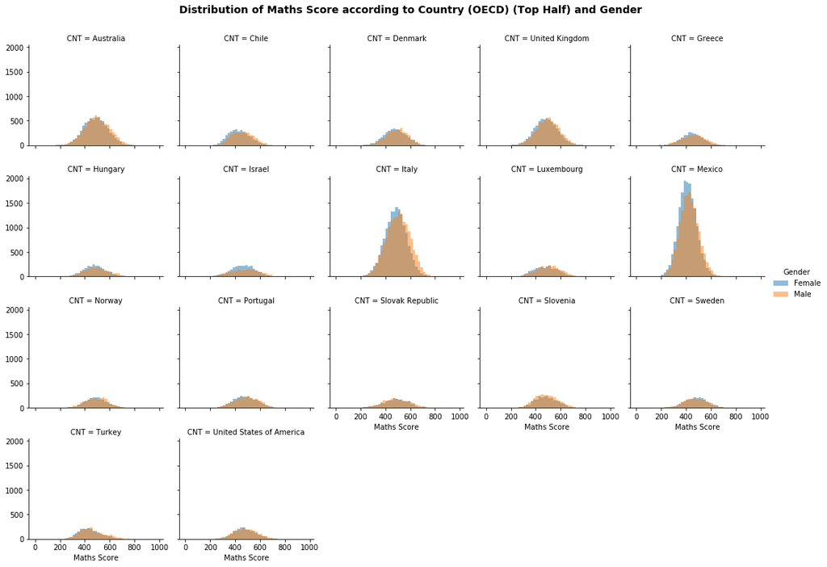

```python
# FacetGrid for distribution of maths score according to country (OECD) (top half) and gender
#plt.figure(figsize=[14.70, 8.27])
df['Maths Score'] = df['PV1MATH']
df['Gender'] = df['ST04Q01']
binsize = 20
bins = np.arange(0, df['Maths Score'].max()+binsize, binsize)

plt.tight_layout();
g = sb.FacetGrid(df[(df['OECD']=='OECD') & (df['CNT'].isin(OECD_top_countries))], col='CNT', hue='Gender', col_wrap=5, margin_titles=True, height = 10.27/4, aspect = (14.70/5)/(10.27/4))
g.map(plt.hist, 'Maths Score', bins = bins, alpha=0.5)
g.add_legend()
g.fig.suptitle('Distribution of Maths Score according to Country (OECD) (Top Half) and Gender', fontsize=14, weight='bold', y = 1.04);
```

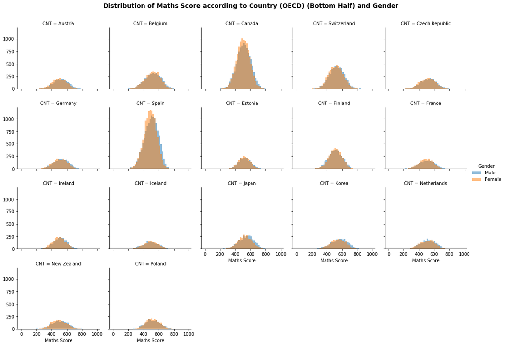

```python
# FacetGrid for distribution of maths score according to country (OECD) (bottom half) and gender
#plt.figure(figsize=[14.70, 8.27])
df['Maths Score'] = df['PV1MATH']
df['Gender'] = df['ST04Q01']
binsize = 20
bins = np.arange(0, df['Maths Score'].max()+binsize, binsize)

plt.tight_layout();
g = sb.FacetGrid(df[(df['OECD']=='OECD') & (df['CNT'].isin(OECD_bottom_countries))], col='CNT', hue='Gender', col_wrap=5, margin_titles=True, height = 10.27/4, aspect = (14.70/5)/(10.27/4))
g.map(plt.hist, 'Maths Score', bins = bins, alpha=0.5)
g.add_legend()
g.fig.suptitle('Distribution of Maths Score according to Country (OECD) (Bottom Half) and Gender', fontsize=14, weight='bold', y = 1.04);
```

## Educational Qualification (Mother)

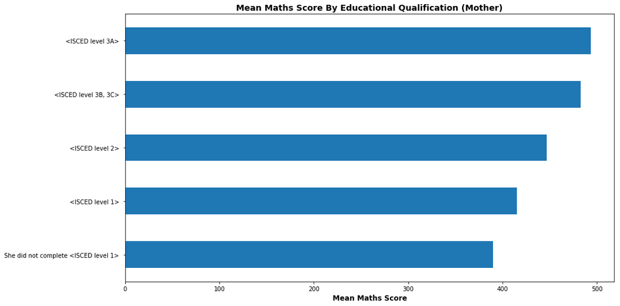

```python
# Mean Maths Score
plt.figure(figsize=[14.70, 8.27])
df.groupby('ST13Q01').mean()['PV1MATH'].sort_values(ascending=True).plot(kind='barh')
plt.title('Mean Maths Score by Educational Qualification (Mother)'.title(), fontsize=14, weight='bold')
plt.xlabel('Mean Maths Score'.title(), fontsize=12, weight='bold')
plt.ylabel(''.title(), fontsize=12, weight='bold')
plt.show()
```

## Educational Qualification (Father)

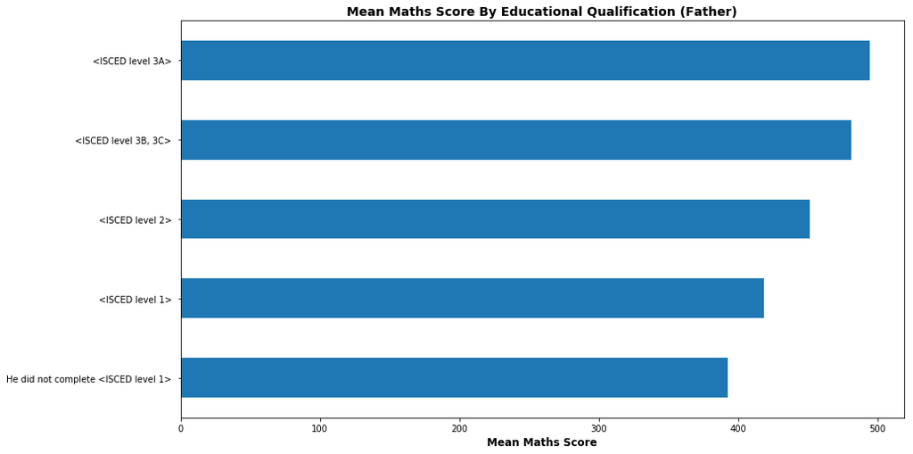

```python
# Mean Maths Score
plt.figure(figsize=[14.70, 8.27])
df.groupby('ST17Q01').mean()['PV1MATH'].sort_values(ascending=True).plot(kind='barh')
plt.title('Mean Maths Score by Educational Qualification (Father)'.title(), fontsize=14, weight='bold')
plt.xlabel('Mean Maths Score'.title(), fontsize=12, weight='bold')
plt.ylabel(''.title(), fontsize=12, weight='bold')
plt.show()
```

## Relationships between Maths, Reading and Science Scores

In general, the mean scores for maths, reading and science are all positively correlated strongly with one another. This means that a student who is strong in maths will usually be strong in science and reading as well, and vice versa. There is no significant difference in the trends observed for genders.

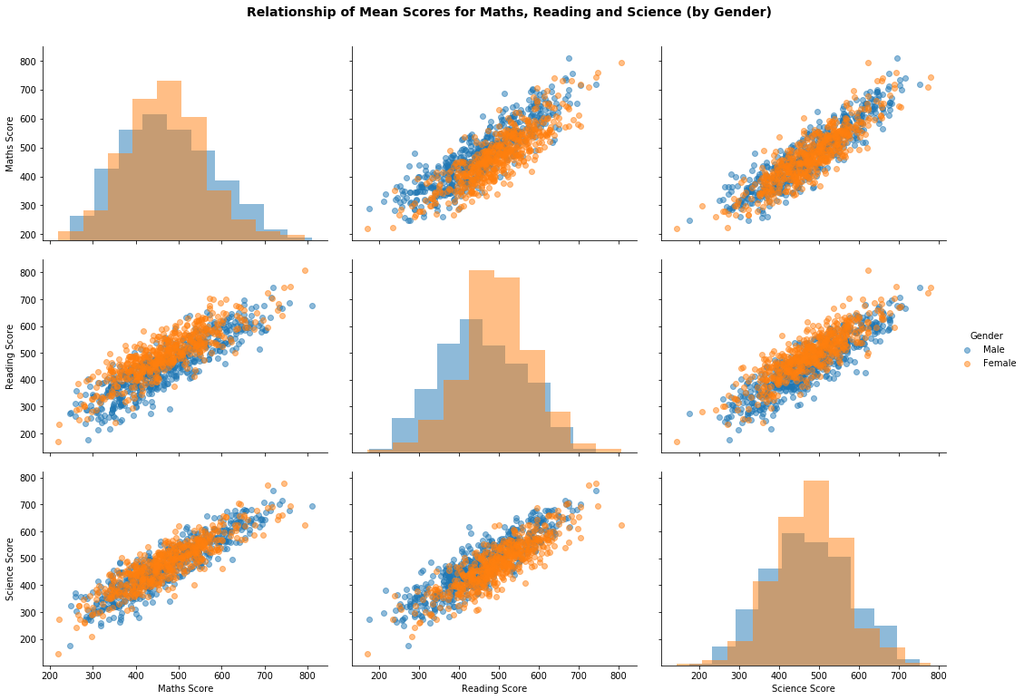

```python
# PairGrid for mean scores (by gender)

# Sample 1000 students so that plots are clearer and they render faster
samples = np.random.choice(df.shape[0], 1000, replace = False)
df_samp = df.loc[samples,:]

df['Maths Score'] = df['PV1MATH']
df['Reading Score'] = df['PV1READ']
df['Science Score'] = df['PV1SCIE']
df['Gender'] = df['ST04Q01']

plt.tight_layout();
g = sb.PairGrid(data=df_samp, vars = ['Maths Score', 'Reading Score', 'Science Score'], hue='Gender', height = 10.27/3, aspect = (14.70/3)/(10.27/3))
g.map_diag(plt.hist, alpha=0.5)
g.map_offdiag(plt.scatter, alpha=0.5)
g.add_legend()
g.fig.suptitle('Relationship of Mean Scores for Maths, Reading and Science (by Gender)', fontsize=14, weight='bold', y = 1.04);
```